# MSE210 Lab 10: Introduction to regression (building emperical models with exp.)

In this lab you will be building a model for a thermistor. The resistance of a thermistor depends very strongly on its temperature. Indeed the word thermistor is a combination of thermal and resistor. Recal that resistors get hotter as we pass more current through them. (More accurately, the heat generation increases, and the resistor’s temperature increases until the increased heat transfer-rate matches the heat generated). In this experiment, we will assume that the resistance of a thermistor is a function of the current. This is a fairly accurate assumption as long as you do not touch the thermistor or otherwise change the ambient conditions.

Note: This sample report was generated using a representative data. Your results would likely be a bit different

## 1. In-person part of the lab

Warning

Note 1: The current through the thermistor or the voltage across it must NEVER exceed 10mA or 30V.

Note 2: Do not touch the thermistor during the experiments (use the breadboard).

Note 3: The thermistor can become very hot for currents larger than a few mA.

Note 4: After changing the voltage, wait for at least one full minute before you take your measurement.

1. Measure and record the resistance of your thermistor with the multimeter (report 4 significant digits). We refer to this value as R<sub>0</sub>.
2. Use the DC power supply to set the voltage across the thermistor and measure the current through it with your multimeter (see Figure). Apply 8 DC voltages from 1 to 10V range (inclusive, i.e the count includes both extremes) and record the resulting currents (in mA) with 4 significant digits for 2 sets of data as described below.
   - First increase the voltage from 1 to 10V. (Note: Your data need not be evenly spaced)
   - Decrease the voltage from 10 to 1V. (Note: Your data could be different from the previous case, but it might be easier to use the same voltages)

   Transfer the all of this data to a csv file “low_v.csv”. The 1st row of the file will have the headers V,I; the next rows will have data in the form <voltage>, <current> after you complete the next part.

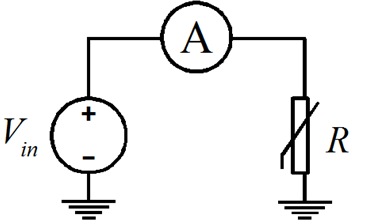

   Circuit to measure the resistance

3. Apply 8 DC voltages in the 12.5 to 30V range (inclusive) and record the resulting currents with 4 significant digits in the table below. Record your observations in the table below for 2 sets of data as described below .
   - First increase the voltage from 12.5 to 30V. (Note: Your data need not be evenly spaced)
   - Decrease the voltage from 30 to 12.5V. (Note: Your data could be different from the previous case, but it might be easier to use the same voltages)

   Transfer the all of this data to a csv file “high_v.csv”. Once again the 1st row of the file will have the headers V,I; the next rows will have data in the form <voltage>, <current>.

## 2. Getting Started

### Load packages

In this lab, you will explore and visualize the data using the **tidyverse** suite of packages. You will also use the **statsr** package to select a regression line that minimizes the sum of squared residuals and the **broom** package to tidy regression output.

Let’s load the packages.

```r
library(tidyverse)
library(openintro)
library(statsr)
library(broom)
```

### Creating a reproducible lab report

To create your new lab report, in RStudio, go to New File -> R Markdown… Then, choose From Template and then choose `Lab Report for OpenIntro Statistics Labs` from the list of templates.

### The data

The data we’re working with the data you collected during you experiments. Let us strat with the low voltage data “lowV.csv”. Copy your data to a folder called “data”

```r
low_v = read_csv("data/low_v.csv", show_col_types = FALSE)
high_v = read_csv("data/high_v.csv", show_col_types = FALSE)
```

You may wish to combine the data using “bind_rows”.

```r
all_v = bind_rows(low_v,high_v)
glimpse(all_v)
```

[output not shown]

1. What are the dimensions of the dataset? What does each row represent?
2. We can visualize parts of the data (for instance V <= 5 )

For now we will treat the data separately.

3. What type of plot would you use to display the relationship between the voltage as a function of current ?

5. If the relationship looks linear, we can quantify the strength of the relationship with the correlation coefficient.

   ```r
   low_v5 %>%
     summarise(cor(I, V))
   ```

### Sum of squared residuals

In this section, you will use an interactive function to investigate what we mean by “sum of squared residuals”. It would be better to run this function in your console, rather than in your markdown document. Running the function also requires that the data is loaded in your environment. You will also need to make sure the Plots tab in the lower right-hand corner has enough space to make a plot.

Think back to the way that we described the distribution of a single variable. Recall that we discussed characteristics such as center, spread, and shape. It’s also useful to be able to describe the relationship of two numerical variables, such as `I` and `V` above.

4. Looking at your plot from the previous exercise, describe the relationship between these two variables. Make sure to discuss the form, direction, and strength of the relationship as well as any unusual observations.

   Just as you’ve used the mean and standard deviation to summarize a single variable, you can summarize the relationship between these two variables by finding the line that best follows their association. Use the following interactive function to select the line that you think does the best job of going through the cloud of points.

   ```r
   plot_ss(x = I, y = V, data = low_v5)
   ```

   After running this command, you’ll be prompted to click two points on the plot to define a line. Once you’ve done that, the line you specified will be shown in black and the residuals in blue.

   If your plot is appearing below your code chunk and won’t let you select points to make a line, take the following steps:
   - Go to the Tools bar at the top of RStudio
   - Click on “Global Options…”
   - Click on the “R Markdown pane” (on the left)
   - Uncheck the box that says “Show output inline for all R Markdown documents”

   Recall that the residuals are the difference between the observed values and the values predicted by the line:

   $$e_i = y_i - \hat{y}_i$$

   The most common way to do linear regression is to select the line that minimizes the sum of squared residuals. To visualize the squared residuals, you can rerun the plot command and add the argument `showSquares = TRUE`.

   ```r
   plot_ss(x = I, y = V, data = low_v5, showSquares = TRUE)
   ```

   Note that the output from the `plot_ss` function provides you with the slope and intercept of your line as well as the sum of squares.
5. Using `plot_ss`, choose a line that does a good job of minimizing the sum of squares. Run the function several times. What was the smallest sum of squares that you got? How does it compare to your neighbours?

## 3. The linear model

It is rather cumbersome to try to get the correct least squares line, i.e. the line that minimizes the sum of squared residuals, through trial and error. Instead, you can use the `lm` function in R to fit the linear model (a.k.a. regression line).

```r
m1 <- lm(V ~ I, data = low_v5)
```

The first argument in the function `lm()` is a formula that takes the form `y ~ x`. Here it can be read that we want to make a linear model of `V` as a function of `I`. The second argument specifies that R should look in the data frame to find the two variables.

**Note:** Piping **will not** work here, as the data frame is not the first argument!

The output of `lm()` is an object that contains all of the information we need about the linear model that was just fit. We can access this information using the `tidy()` function.

```r
tidy(m1)
```

[output not shown]

We can assess model fit using $R^2$, the proportion of variability in the response variable that is explained by the explanatory variable. We use the `glance()` function to access this information.

```r
glance(m1)
```

[output not shown]

1. However the original model does (may) not make physical sense since the voltage at zero current is not zero. To force this physical constraint, we need to force the intercept to zero by replacing the formula `y ~ x` with `y ~ 0+x`.

### Prediction and prediction errors

Let’s create a scatterplot with the least squares line for `m2` laid on top.

```r
ggplot(data = low_v5, aes(x = I, y = V)) +
  geom_point() +
  geom_smooth(method = "lm", formula = y ~ 0+x, se = FALSE)
```

[output not shown]

Here, we are literally adding a layer on top of our plot. `geom_smooth` creates the line by fitting a linear model. It can also show us the standard error `se` associated with our line, but we’ll suppress that for now.

This line can be used to predict $y$ at any value of $x$. When predictions are made for values of $x$ that are beyond the range of the observed data, it is referred to as *extrapolation* and is not usually recommended. However, predictions made within the range of the data are more reliable. They’re also used to compute the residuals.

2. If someone saw the least squares regression line and not the actual data, how would they predict a Voltage for I not in your data ? Is it valid to use model to predict Voltage for 5mA ?